# R6 Introduction

Greg Snow

September 26, 2019

## Law of Programming

Every program can be shortened by at least one line and has at least one bug.

By induction, every program can be reduced to 1 line that does not work.

# Functional vs. Object Oriented programming

## Functional Programming

- Function results based only on inputs.
  - Same inputs imply same output, regardless of other variables/options.
- Functions only return results, do not change inputs.
  - Inputs may be copied internally.
- Clean, simple, predictable.
  - Sometimes redundant, inefficient, and a pain to pass everything around.

## Pass by Reference

- Instead of passing in data, pass the address in memory where the data is located
- Function can access data without copying
- Function can also change the data in place
- Less redundant, more efficient, less of a pain in some ways
  - Not clean, Not simple, Not predictable

## Object Oriented Programming

- Data/Object focused, methods act on specific objects
- Object can be modified by its methods
- Can restrict changing object to methods to avoid some reference problems

S/R is a mixture of all these (possibly plus others).

```r
fortune(322)
```

```
##
## As long as R stayed in Ross and Robert's computer lab, R could be
## perfectly clean and beautiful. [...]
## The moral of the story is that if you want to create a beautiful
## language, for god's sake don't make it useful.
##    -- Patrick Burns (Inferno-ish R)
##       CambR User Group Meeting, Cambridge (May 2012)
```

## Why use objects?

- Keep related variables together.
- Keep information between function calls.
- Avoid global variables and options.
- All the cool kids are doing it.

# Global variables

## Quick Quiz

```r
x <- 10
y <- FunctionThatUsesGlobalVariables(x)
```

What is the value of `x`?

```r
fortune(174)
```

```
##
## I wish <<- had never been invented, as it makes an esoteric and
## dangerous feature of the language *seem* normal and reasonable. If
## you want to dumb down R/S into a macro language, this is the operator
## for you.
##    -- Bill Venables
##       R-help (July 2001)
```

```r
fortune(236)
```

```
##
## The only people who should use the assign function are those who
## fully understand why you should never use the assign function.
##    -- Greg Snow
##       R-help (July 2009)
```

```r
fortune(106)
```

```
##
## If the answer is parse() you should usually rethink the question.
##    -- Thomas Lumley
##       R-help (February 2005)
```

```r
fortune(181)
```

```
##
## Personally I have never regretted trying not to underestimate my own
## future stupidity.
##    -- Greg Snow (explaining why eval(parse(...)) is often suboptimal,
##       answering a question triggered by the infamous fortune(106))
##       R-help (January 2007)
```

# Quick History

## S3

Version 3 of the original S language included generic functions.

- Data object can have a “class”.
- Generic functions call another function/method based on the class.
  - Quick and simple
  - No checking to make sure objects have the correct fields

## S4

Version 4 of S implemented a new object oriented paradigm.

- Objects and methods must now be registered
- Safer because objects guaranteed to have correct fields
- More work up front
- Less flexible

## Reference Classes

R introduced Reference classes that are more like OOP languages like smalltalk, Java, C++, etc.

- Methods belong to an object rather than being generic
- Based on S4
- Still Somewhat complicated

Some people started calling these R5 objects, but the authors did not like that.

## R6

A new package that implements Reference Class objects based on S3 objects in a simple but powerful way.

# R6 objects

## Creating an object

- Assign the result of `R6Class` to a name.
- Pass lists of fields (variables) and methods (functions).
- Use `new` method and save result.
- Use `self$<name>` and `private$<name>` to reference fields.

## public

- List of fields and methods that will be visible and modifiable when using the object

## private

- List of fields and methods that can be accessed from private and public methods, but not visible or modifiable from outside.

## active

- List of active bindings, functions that can be treated like variables.

## Special methods

- initialize: run when a new object is created
- finalize: run when an object is removed
- clone: used to make a copy of the object
- print: display object summary or contents

# Progress bar example

## Functional form

```r
student_sim <- function(n){
  x <- rnorm(n)
  mean(x)/(sd(x)/sqrt(n))
}

pb <- winProgressBar(max=10000)
setWinProgressBar(pb, value=0)
out <- replicate(10000, {
  i <- getWinProgressBar(pb) + 1
  setWinProgressBar(pb, value=i)
  student_sim(25)
})
close(pb)
```

## R6 progress bar wrapper

```r
ProgBar <- R6Class("ProgBar",
                   public = list(
                     initialize = function(max,...) {
                       private$pb <- winProgressBar(max=max)
                     },
                     inc = function(amount=1) {
                       private$i <- private$i + amount
                       setWinProgressBar(private$pb, value=private$i)
                       invisible(self)
                     },
                     reset = function(value=0) {
                       private$i <- value
                       setWinProgressBar(private$pb, value=private$i)
                       invisible(self)
                     },
                     val=function() {
                       private$i
                     }
                   ),
                   private = list(
                     pb = NULL,
                     i = 0,
                     finalize = function(...) {
                       close(private$pb)
                     }
                   )
                )
```

## R6 Progress bar example

```r
pb <- ProgBar$new(10000)

pb$reset()
out <- replicate(10000, {
  pb$inc()
  student_sim(25)
})

rm(pb)
gc()
```

## Multiple bars for nested simulation

```r
n.vec <- c(5, 10, 15, 20, 25, 30, 40, 50, 75, 100)

pb.o <- ProgBar$new(length(n.vec))
pb.o$reset()

pb.i <- ProgBar$new(10000)

out <- lapply(n.vec, function(n) {
  pb.o$inc()
  pb.i$reset(0)
  replicate(10000, {
    pb.i$inc()
    student_sim(n)
  })
})

rm(pb.o, pb.i)
gc()
```

## Include function in object

```r
ProgBar$set('public', "StuSim", function(n){
  self$inc()
  student_sim(n)
})

pb <- ProgBar$new(10000)

pb$reset()
out <- replicate(10000, pb$StuSim(25))

rm(pb)
```

## Chaining

```r
pb <- ProgBar$new(100)
pb$val()
# 0

pb$inc()$inc()$inc()$val()
# 3

pb$reset(50)$val()
# 50

pb$reset()$val()
# 0

rm(pb)
```

## Package purrrogress

The purrrogress package does a lot of this for you (and more).

# Memoizing

## Memoizing

```r
FibGen <- R6Class("FibGen",
                  public=list(
                    curmax=2,
                    fibvals = c(1,1),
                    fib = function(n) {
                      if(n <= self$curmax) {
                        return(self$fibvals[n])
                      } else {
                        cat("generating values", self$curmax+1, 'to', n, "\n")
                        for(i in (self$curmax+1):n) {
                          self$fibvals[i] <- self$fibvals[i-1] + self$fibvals[i-2]
                        }
                        self$curmax <- n
                        return(self$fibvals[n])
                      }
                    }
                  ))
```

## Memoizing

```r
myfib <- FibGen$new()
myfib$fib(5)
```

```
## generating values 3 to 5
```

```
## [1] 5
```

```r
myfib$fib(3)
```

```
## [1] 2
```

```r
myfib$fib(10)
```

```
## generating values 6 to 10
```

```
## [1] 55
```

```r
myfib$fib(7)
```

```
## [1] 13
```

```r
myfib$fibvals
```

```
##  [1]  1  1  2  3  5  8 13 21 34 55
```

# Keeping function values

## Optim Example

```r
RBF <- R6Class('RBF',
               public = list(
                 x1 = numeric(0),
                 x2 = numeric(0),
                 fr = function(x) {
                   x1 <- x[1]
                   x2 <- x[2]
                   self$x1 <- c(self$x1, x1)
                   self$x2 <- c(self$x2, x2)
                   100 * (x2 - x1*x1)^2 + (1-x1)^2
                 }
               ))
rbf <- RBF$new()

(res <- optim(c(-1.2, 0), rbf$fr))
```

```
## $par
## [1] 1.000026 1.000138
##
## $value
## [1] 7.434192e-07
##
## $counts
## function gradient
##      143       NA
##
## $convergence
## [1] 0
##
## $message
## NULL
```

## Path

```r
tmp1 <- seq(-1.25, 1.1, length.out=100)
tmp2 <- seq(-0.1, 1.15, length.out=100)
z <- outer(tmp1, tmp2, function(x1,x2) 100*(x2-x1*x1)^2 + (1-x1)^2)
image(tmp1, tmp2, z)
points(c(-1.2,1),c(0,1), col=c('green','red'), pch=16, cex=2)
lines(rbf$x1, rbf$x2)
```

## Path

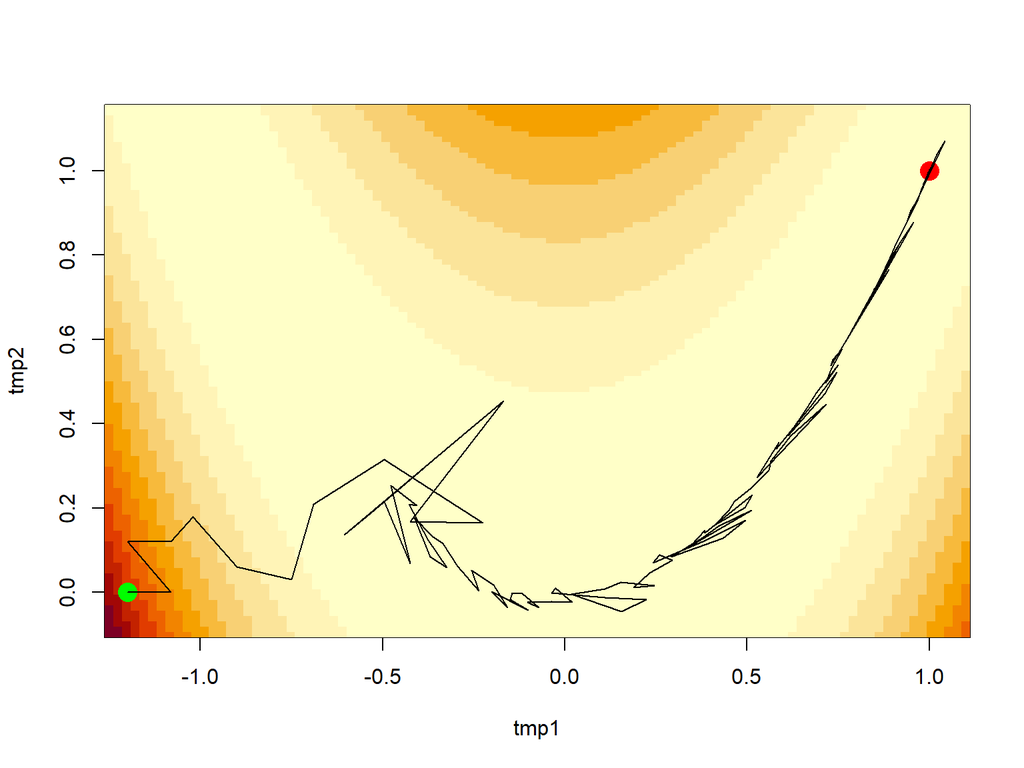

# Active Bindings

## Mimic syntax like `x++` and `x += y` from Perl/C++/etc.

```r
Inc <- R6Class('Inc',
               public=list(
                 value=0
               ),
               active = list(
                 pp = function(value) {
                   if(missing(value)) { #x++ (actually ++x)
                     self$value <- self$value + 1
                     return(self$value)
                   } else {  # x += y
                     self$value <- self$value + value
                   }
                 }
               )
               )
```

## Example

```r
x <- Inc$new()
x$value <- 5
x$pp
```

```
## [1] 6
```

```r
x$pp <- 10
x$value
```

```
## [1] 16
```

## Example

```r
i <- Inc$new()

x <- 1e7
while( abs(x-1) > 0.001 ) {
  x <- sqrt(x)
  if( i$pp > 10 ) {
    cat("Maximum Iterations Reached\n")
    break
  }
}

for(k in longvector) {
  setWinProgressBar(pb, value=i$pp)
  LongRunningFunction(k)
}
```

# Adaptive Integration example (recursion through looping)

## Trapazoid object

```r
TrapObj <- R6Class(
  "TrapObj",
  public = list(
    x.left = numeric(1),
    y.left = numeric(1),
    x.right = numeric(1),
    y.right = numeric(1),
    split = function(fun){
      left <- self$clone()
      right <- self$clone()
      new.x <- (self$x.left + self$x.right)/2
      new.y <- if(missing(fun)) {
        (self$y.left + self$y.right)/2
      } else {
        fun(new.x)
      }
      left$x.right <- right$x.left <- new.x
      left$y.right <- right$y.left <- new.y
      list(left=left, right=right)
    },
    plot = function(col=NA){
      polygon(c(self$x.left, self$x.left, self$x.right, self$x.right),
              c(0,self$y.left, self$y.right, 0), border='blue', col=col)
    }
  ),
  active = list(
    area = function() (self$x.right - self$x.left) *
      (self$y.right + self$y.left)/2
  )
)
```

## Stack

```r
Stack <- R6Class(
  "Stack",
  public = list(
    length = 0L,
    stack = vector(mode='list', length=10),
    push = function(obj) {
      if( length(self$stack) <= self$length ) {
        self$stack[2*self$length] <- list(NULL)
      }
      self$length <- self$length + 1
      self$stack[[self$length]] <- obj
      invisible(self)
    },
    pop = function() {
      if(self$length < 1) stop('Stack is empty')
      tmp <- self$stack[[self$length]]
      self$length <- self$length - 1
      return(tmp)
    }
  )
)
```

## Adaptive Integration

```r
cand <- Stack$new()
res <- Stack$new()

#myfun <- function(x) dnorm(x, 0, 1)
myfun <- function(x) sin(x^2) + 1.25

start <- TrapObj$new()
start$x.left <- 0
start$y.left <- myfun(0)
start$x.right <- 2.5
start$y.right <- myfun(2.5)

cand$push(start)
area <- 0
tol <- 0.0005

while(cand$length){
  curve(myfun(x), from=0, to=2.5, col='lightgrey', lwd=5, ylim=c(0,2.5))
  for(i in seq_len(cand$length)) cand$stack[[i]]$plot("#ff000033")
  for(i in seq_len(res$length)) res$stack[[i]]$plot("#ff000033")
  cur <- cand$pop()

  tmp <- cur$split(myfun)
  for(i in 1:2) tmp[[i]]$plot("#0000ff33")

  if(abs(cur$area - tmp$left$area - tmp$right$area) <= tol) {
    res$push(tmp$left)$push(tmp$right)
    area <- area + tmp$left$area + tmp$right$area
  } else {
    cand$push(tmp$right)$push(tmp$left)
  }
}
```

## Adaptive Integration

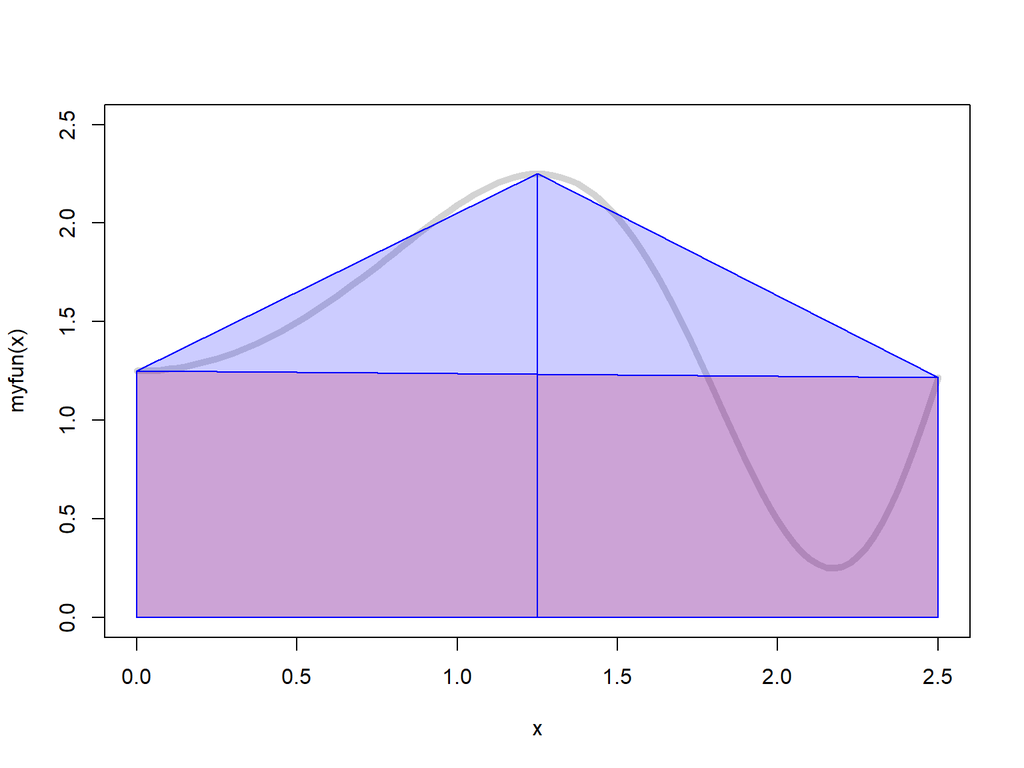

## Results

```r
curve(myfun(x), from=0, to=2.5, col='green', lwd=5, ylim=c(0,2.5))
for(i in seq_len(res$length)) {
  res$stack[[i]]$plot()
}
text(0.5, 2.3, paste('Est:',round(area,4)), adj=1)
text(0.5, 2.1, paste('Int:',round(integrate(myfun, lower=0, upper=2.5)$value,4)), adj=1)
```

## Results

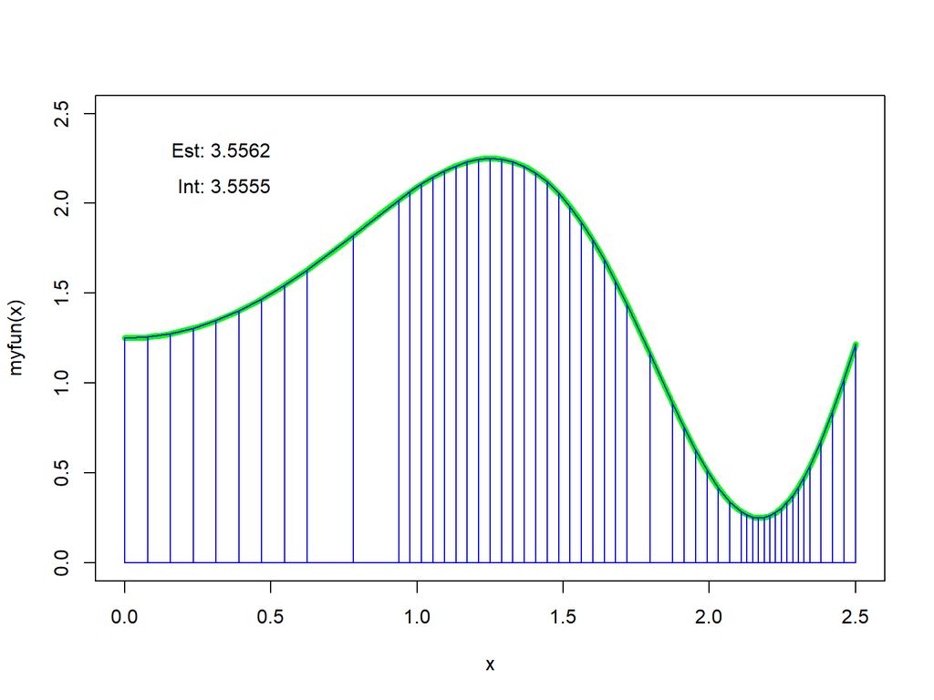

## R6DS

The R6DS (Data Structures) package implements stacks, queues, and other data structures using R6 objects, probably better than I have here.

# Not covered

## Not covered

- Inheritance
- Debugging
- Deep Cloning (reference objects)
- Non-portable R6 objects
- Lots of theory and other things